# Getting Started with TernTables

## Overview

**TernTables** is built for clinical researchers who need to go from raw data to a manuscript-ready Word table — with variable detection, statistical test selection, and formatting all handled automatically.

Given a data frame and an optional grouping variable, it automatically:

- Detects each variable’s type (continuous, binary, categorical)
- Selects the appropriate statistical test
- Formats *P* values and summary statistics for publication-ready tables
- Exports directly to a styled `.docx` Word file and generates a boilerplate statistical methods paragraph
- Returns a tibble for inspection, Excel export, or further analysis in R

Three table types are supported: **descriptive summaries** (single cohort, no comparisons), **two-group comparisons** (with optional unadjusted odds ratios), and **comparisons across three or more groups**.

> **No R required?** TernTables is available as a free point-and-click web application at [tern-tables.com](https://tern-tables.com/). Upload a CSV or XLSX, configure your table, and download a formatted Word document — all without writing a line of code. The web app is powered by this package, so the statistical methods, normality routing, and Word output are identical. A built-in side panel shows the R commands running in the background and the full script can be downloaded at the end of your session, making every analysis fully transparent and reproducible. For scripted or reproducible workflows, the R package (this vignette) remains the canonical reference.

> **Scope — independent observations only:** all statistical tests in `ternG()` assume each row represents a distinct, unrelated subject. TernTables is **not** designed for repeated-measures, longitudinal, or clustered data (e.g. pre/post measurements, matched pairs, or patients nested within sites). Applying it to such data would violate the independence assumption shared by all tests in the package and produce invalid *P* values.

## Example Dataset

```r
data(tern_colon)
```

`tern_colon` is bundled with TernTables. It is derived from `survival::colon` and contains 929 patients from a landmark colon cancer adjuvant chemotherapy trial (Moertel et al., 1990), filtered to the recurrence endpoint — one row per patient. See `?tern_colon` for full details.

Key variables used in these examples:

| Column | Description |
| --- | --- |
| `Age_Years` | Age at registration (years) |
| `Sex` | Female / Male |
| `Colonic_Obstruction` | Colonic obstruction present — n (%) |
| `Bowel_Perforation` | Bowel perforation present — n (%) |
| `Positive_Lymph_Nodes_n` | Number of positive lymph nodes |
| `Over_4_Positive_Nodes` | More than 4 positive lymph nodes — n (%) |
| `Tumor_Adherence` | Tumour adherence to nearby organs — n (%) |
| `Tumor_Differentiation` | Well / Moderate / Poor |
| `Extent_of_Local_Spread` | Depth of tumour penetration (4 levels) |
| `Recurrence` | No Recurrence / Recurrence — **2-group** |
| `Treatment_Arm` | Levamisole + 5FU / Levamisole / Observation — **3-group** |

## Preprocessing Raw Data (`ternP`)

If your source is a raw CSV or XLSX file — rather than an already-clean R object — use `ternP()` to standardize it before passing it to `ternG()` or `ternD()`. It handles the messiness most commonly introduced by manual data entry or spreadsheet workflows:

| Transformation | What it fixes |
| --- | --- |
| String NA conversion | `"NA"`, `"na"`, `"Na"`, `"unk"` → `NA` |
| Whitespace trimming | Leading/trailing spaces in character columns |
| Empty column removal | 100% `NA` columns silently dropped |
| Blank row removal | Rows where every cell is `NA` |
| Case normalization | `"fEMALE"` / `"Female"` unified to title case |

`ternP()` also applies two **hard stops** before any cleaning takes place: it errors immediately if any column name matches a protected health information (PHI) pattern (e.g. `MRN`, `DOB`, `FirstName`), or if any unnamed column contains data.

```r
# Load a messy CSV shipped with the package
path <- system.file("extdata/csv", "tern_colon_messy.csv",
                    package = "TernTables")
raw    <- readr::read_csv(path, show_col_types = FALSE)
result <- ternP(raw)
# The print method fires automatically, summarising every transformation applied.
```

The printed summary identifies each transformation and shows the final dimensions of the cleaned data. If the data was already clean, a single “No transformations required” line appears.

Three items are returned in the result object:

```r
result$clean_data    # Cleaned, analysis-ready tibble
result$sparse_rows   # Rows with >50% NA (retained, not removed — review these)
result$feedback      # Named list; NULL elements mean no action was taken
```

To write a Word document recording the cleaning steps, call `write_cleaning_doc()`. It is fully dynamic — only paragraphs for triggered transformations are written, so the document is concise for already-clean data.

```r
write_cleaning_doc(result,
                   filename = file.path(out_dir, "cleaning_summary.docx"))
```

Once preprocessing is complete, pass `result$clean_data` directly to `ternD()` or `ternG()`:

```r
tbl <- ternG(result$clean_data,
             exclude_vars = c("ID"),
             group_var    = "Recurrence")
```

## Descriptive Table (`ternD`)

Use `ternD()` for a single cohort with no group comparisons — the standard “Table 1” in a cohort description. Pass `output_docx` to write a publication-ready Word file in the same call; pass `output_xlsx` to also save the tibble as an Excel file. Use `category_start` to insert bold section headers grouping related variables; anchors can be either the raw column name or the cleaned display label.

```r
tbl_descriptive <- ternD(
  data             = tern_colon,
  exclude_vars     = c("ID"),
  output_docx      = file.path(out_dir, "Tern_descriptive.docx"),
  methods_filename = file.path(out_dir, "TernTables_methods.docx"),
  open_doc         = FALSE,
  category_start = c(
    "Patient Demographics"  = "Age (yr)",
    "Surgical Findings"     = "Colonic Obstruction",
    "Tumor Characteristics" = "Positive Lymph Nodes (n)",
    "Outcomes"              = "Recurrence"
  )
)
tbl_descriptive
```

Continuous variables show mean ± SD or median [IQR] based on the four-gate ROBUST normality algorithm (n < 3 fail-safe, skewness/kurtosis check, CLT at n ≥ 30, Shapiro-Wilk for small samples). Columns whose values are exactly Y/N, YES/NO, or numeric 0/1 are detected as binary and shown as a single n (%) row (the positive/yes count). All other categorical variables — including two-level variables like Male/Female — are shown with each level as an indented sub-row.

Variable names are automatically cleaned for display (`smart_rename = TRUE` by default) — underscores replaced with spaces, capitalisation normalised, and common medical abbreviations formatted (e.g. `Age_Years` → `Age (yr)`, `Positive_Lymph_Nodes_n` → `Positive Lymph Nodes (n)`). Pass `smart_rename = FALSE` to use column names exactly as they appear in the data.

Descriptive summary table exported to Word:

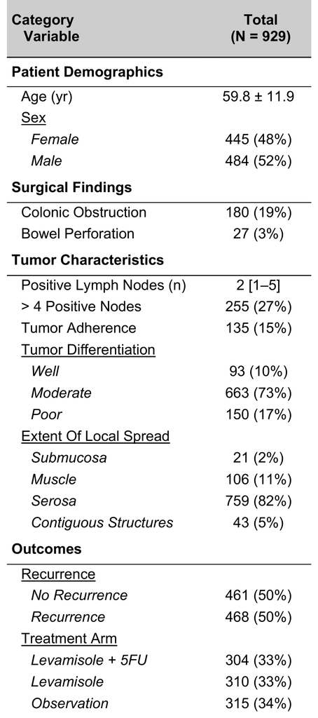

## Two-Group Comparison (`ternG` — 2 levels)

Use `ternG()` to compare variables between two groups. Set `OR_col = TRUE` to add unadjusted odds ratios with 95% CI for binary variables (Y/N, YES/NO, 0/1) and two-level categorical variables such as Male/Female. For two-level categoricals displayed with sub-rows, the reference level (factor level 1 or alphabetical first) shows `1.00 (ref.)`; the non-reference level shows the computed unadjusted OR with 95% CI. Fisher’s exact or Wald is chosen automatically based on expected cell counts. Pass `output_docx` to write the Word table directly; `output_xlsx` exports the tibble to Excel.

```r
tbl_2group <- ternG(
  data             = tern_colon,
  exclude_vars     = c("ID"),
  group_var        = "Recurrence",
  output_docx      = file.path(out_dir, "Tern_2_group.docx"),
  methods_filename = file.path(out_dir, "TernTables_methods.docx"),
  open_doc         = FALSE,
  OR_col           = TRUE,
  insert_subheads  = TRUE,
  category_start   = c(
    "Patient Demographics"  = "Age (yr)",
    "Surgical Findings"     = "Colonic Obstruction",
    "Tumor Characteristics" = "Positive Lymph Nodes (n)",
    "Treatment Details"     = "Treatment Arm"
  )
)
tbl_2group
```

The Word table includes an OR column (unadjusted odds ratio with 95% CI for binary variables) and a *P* value column (test *P* value for each variable).

Two-group comparison table exported to Word, with odds ratios and category section headers:

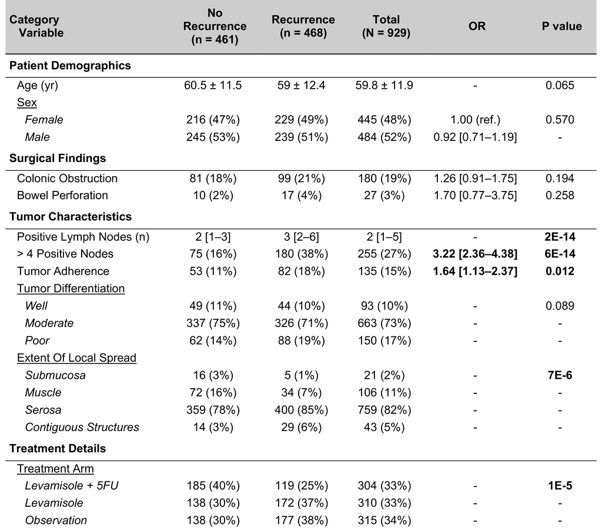

## Three or More Groups (`ternG` — 3+ levels)

The same `ternG()` function handles three or more groups automatically, switching from t-test/Wilcoxon to Welch ANOVA/Kruskal-Wallis as appropriate. Odds ratios are not available for 3+ group comparisons. `consider_normality` controls normality routing; the default (`"ROBUST"`) applies the four-gate algorithm (n < 3 fail-safe → skewness/kurtosis → CLT → Shapiro-Wilk). `FALSE` forces parametric tests throughout; `"FORCE"` forces nonparametric throughout.

Set `post_hoc = TRUE` to run pairwise post-hoc tests automatically when the omnibus *P* < 0.05. The test is matched to the omnibus test used: **Games-Howell** follows Welch ANOVA (parametric path); **Dunn’s test with Holm correction** follows Kruskal-Wallis (non-parametric and ordinal path). Results are appended to each cell as compact letter display (CLD) superscripts — groups sharing a letter are not significantly different after correction. Categorical variables never receive post-hoc testing. When `post_hoc = TRUE` and at least one test fires, an explanatory footnote is added automatically to the Word output.

```r
tbl_3group <- ternG(
  data               = tern_colon,
  exclude_vars       = c("ID"),
  group_var          = "Treatment_Arm",
  group_order        = c("Observation", "Levamisole", "Levamisole + 5FU"),
  output_docx        = file.path(out_dir, "Tern_3_group.docx"),
  methods_filename   = file.path(out_dir, "TernTables_methods.docx"),
  open_doc           = FALSE,
  consider_normality = "ROBUST",
  post_hoc           = TRUE,
  category_start     = c(
    "Patient Demographics"  = "Age (yr)",
    "Surgical Findings"     = "Colonic Obstruction",
    "Tumor Characteristics" = "Positive Lymph Nodes (n)",
    "Outcomes"              = "Recurrence"
  )
)
tbl_3group
```

Three-group comparison table exported to Word with category section headers:

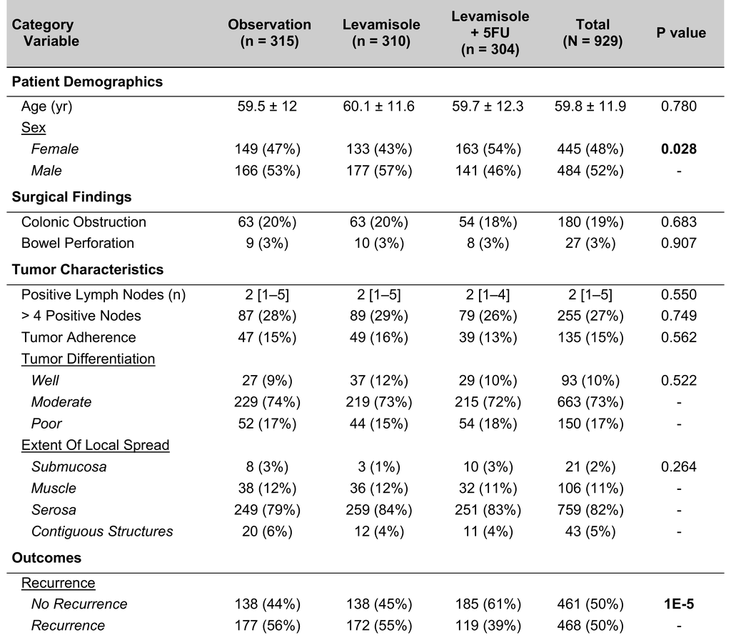

> **Note:** In randomized trials, *P* values for baseline characteristics are conventionally omitted — any observed differences between arms are attributable to chance, not systematic bias, because randomization was the assignment mechanism. The baseline variables above (Patient Demographics, Surgical Findings, Tumor Characteristics) are included here alongside the Outcomes section solely to demonstrate multi-group Welch ANOVA and Kruskal-Wallis testing across the full range of variable types. The clinically meaningful comparison in this table is the outcome: Recurrence by treatment arm.

## BH FDR Correction (`p_adjust`)

When comparing many variables simultaneously, the probability of observing at least one false-positive *P* value by chance increases with the number of tests performed. Set `p_adjust = TRUE` to apply the Benjamini-Hochberg (BH) false discovery rate (FDR) correction (Benjamini & Hochberg, 1995) to all omnibus *P* values after testing. This is appropriate for exploratory comparison tables where the goal is to limit the expected proportion of false discoveries across all tests.

The correction pool is **one *P* value per variable** — sub-rows of multi-level categorical variables share the parent variable’s *P* value and are not double-counted. Post-hoc pairwise *P* values (which already carry within-variable Holm correction) are excluded from the pool.

Control column display with `p_adjust_display`:

- `"fdr_only"` (default) — replaces the standard *P* value column, renaming it `"P value (FDR corrected)"`
- `"both"` — retains the original *P* values and adds the corrected values immediately to the right

```r
tbl_fdr <- ternG(
  data             = tern_colon,
  exclude_vars     = c("ID"),
  group_var        = "Recurrence",
  p_adjust         = TRUE,
  p_adjust_display = "both",   # show raw AND FDR-corrected P values
  methods_doc      = FALSE
)
```

## Row Percentages (`percentage_compute`)

By default, categorical percentages are **column percentages** — for each group, what proportion had that level. Set `percentage_compute = "row"` to use **row percentages** instead: for each category level, what proportion falls in each group. The Total column is automatically suppressed when `percentage_compute = "row"` (it would show 100% for every level, which is uninformative).

Row percentages are useful when the clinical question is about how a characteristic is distributed across arms, rather than within-arm prevalence — e.g., *“of all patients who had colonic obstruction, what proportion recurred?”* rather than *“what proportion of each recurrence group had obstruction?”*

```r
tbl_rowpct <- ternG(
  data               = tern_colon,
  vars               = c("Tumor_Differentiation", "Extent_of_Local_Spread",
                         "Colonic_Obstruction"),
  group_var          = "Recurrence",
  percentage_compute = "row",
  output_docx        = file.path(out_dir, "Tern_row_pct.docx"),
  open_doc           = FALSE,
  citation           = FALSE
)
```

## Suppressing P Values (`show_p`) and Showing Missingness (`show_missing`)

Set `show_p = FALSE` to produce a descriptive-only grouped table — group columns with summary statistics, but no *P* value, OR, test, or normality columns. Useful for baseline characteristic tables in randomised trials where hypothesis testing is not the intent.

```r
tbl_desc_grouped <- ternG(
  data         = tern_colon,
  exclude_vars = c("ID"),
  group_var    = "Treatment_Arm",
  show_p       = FALSE,
  output_docx  = file.path(out_dir, "Tern_no_pval.docx"),
  open_doc     = FALSE,
  citation     = FALSE
)
```

Set `show_missing = TRUE` to append a `Missing: n (%)` sub-row beneath each variable. A footnote is added automatically:

```r
tbl_with_missing <- ternG(
  data         = tern_colon,
  exclude_vars = c("ID"),
  group_var    = "Recurrence",
  show_missing = TRUE,
  output_docx  = file.path(out_dir, "Tern_missing.docx"),
  open_doc     = FALSE,
  citation     = FALSE
)
```

## Word Output Formatting

Two optional parameters control text that appears outside the table body in the exported Word document.

**`table_caption`** places a bold size-11 Arial caption above the table, single-spaced with a small gap between the caption and the table:

```r
tbl_descriptive <- ternD(
  data          = tern_colon,
  exclude_vars  = c("ID"),
  output_docx   = file.path(out_dir, "Tern_descriptive.docx"),
  table_caption = "Table 1. Baseline patient characteristics."
)
```

**`table_footnote`** adds a merged footer row below the table in size-6 Arial italic, bordered above and below by a double rule. Pass a single string or a character vector for multiple lines (lines are joined with a line break inside the same cell — no extra row spacing):

```r
tbl_2group <- ternG(
  data           = tern_colon,
  exclude_vars   = c("ID"),
  group_var      = "Recurrence",
  OR_col         = TRUE,
  output_docx    = file.path(out_dir, "Tern_2_group.docx"),
  table_caption  = "Table 2. Characteristics by recurrence status.",
  table_footnote = c(
    "Abbreviations: OR, odds ratio; CI, confidence interval.",
    "\u2020 P values from chi-square or Wilcoxon rank-sum test.",
    "\u2021 ORs from unadjusted logistic regression."
  )
)
```

Both parameters are also stored in the table’s metadata and reproduced automatically when combining tables with `ternB()`.

**`font_family`** controls the font used in all Word output. Defaults to `getOption("TernTables.font_family", "Arial")`. Set a package-wide default for the session:

```r
options(TernTables.font_family = "Times New Roman")
# All subsequent ternG/ternD/word_export calls use Times New Roman
```

**`plain_header = TRUE`** renders the first column header without the dark background and white text — useful for journal styles that require a plain table header row.

**`variable_footnote`** auto-assigns superscript symbols (`*`, `†`, `‡` …) to named variables and appends definitions below the table. Keys match either the raw column name or the cleaned display label:

```r
tbl <- ternG(
  data              = tern_colon,
  vars              = c("Age_Years", "Sex", "Colonic_Obstruction"),
  group_var         = "Recurrence",
  variable_footnote = c(
    "Age (yr)"            = "Age at registration.",
    "Colonic Obstruction" = "Defined as complete mechanical obstruction on imaging."
  ),
  open_doc          = FALSE,
  citation          = FALSE
)
```

Pass `index_style = "alphabet"` to use Unicode letter superscripts instead of symbols.

**`zero_to_dash = TRUE`** replaces `"0 (0%)"` and `"0 (NaN%)"` cells with `"-"` for cleaner tables when sparse categories are present.

**`round_decimal`** sets the number of decimal places for all continuous summary values (integer; default is 1 decimal place). Use `round_intg = TRUE` to round to whole numbers instead.

## Statistical Test Logic

TernTables selects tests automatically based on variable type and normality:

| Variable type | Test (2 groups) | Test (3+ groups) | Post-hoc (3+ groups, `post_hoc = TRUE`, omnibus *p* < 0.05) |
| --- | --- | --- | --- |
| Binary / Categorical | Fisher’s exact or Chi-squared* | Fisher’s exact or Chi-squared* | — |
| Numeric, normal | Welch’s *t*-test | Welch ANOVA | Games-Howell |
| Numeric, non-normal† | Wilcoxon rank-sum | Kruskal-Wallis | Dunn’s + Holm |

†Includes variables designated as ordinal via `force_ordinal`, which bypass normality testing and always use non-parametric methods. Variables overridden to parametric via `force_normal` always appear in the normal row.

*Fisher’s exact is used when any expected cell count is < 5 (Cochran criterion). If the exact algorithm cannot complete (workspace limit exceeded for large tables), Fisher’s exact with Monte Carlo simulation (B = 10,000; seed fixed via `getOption("TernTables.seed")`, default 42) is used automatically.

Normality routing uses `consider_normality = "ROBUST"` (the default) — a four-gate decision applied per group: (1) any group n < 3 → non-parametric (conservative fail-safe); (2) absolute skewness > 2 or excess kurtosis > 7 in any group → non-parametric regardless of sample size; (3) all groups n ≥ 30 → parametric via the Central Limit Theorem; (4) otherwise Shapiro-Wilk p > 0.05 in all groups → parametric. For 3+ group comparisons, omnibus *P* values are reported. When `post_hoc = TRUE`, pairwise comparisons are performed automatically for continuous and ordinal variables when omnibus *P* < 0.05, using the test paired to the omnibus (Games-Howell or Dunn’s + Holm). CLD superscript letters are appended to cell values; groups sharing a letter are not significantly different. Categorical variables never receive post-hoc testing. `post_hoc` defaults to `FALSE`. Set `consider_normality = TRUE` to use Shapiro-Wilk alone (original behaviour).

| Gate | Condition checked | Routes to | Note |
| --- | --- | --- | --- |
| 1 | Any group n < 3 | Non-parametric | Conservative fail-safe; insufficient data to assess |
| 2 | \|skewness\| > 2 **or** \|excess kurtosis\| > 7 in any group | Non-parametric | Distribution shape precludes parametric assumptions regardless of n |
| 3 | All groups n ≥ 30 | Parametric | Central Limit Theorem |
| 4 | Shapiro-Wilk p > 0.05 in **all** groups | Parametric (pass) / Non-parametric (fail) | Valid only when 3 ≤ n ≤ 5,000; n outside this range routes non-parametric |

> **Note:** The ROBUST algorithm is a pragmatic, automated heuristic designed for consistent clinical reporting — not a formal distributional inference. Gate 3 applies the Central Limit Theorem to the sampling distribution of the mean; it does not assert that the underlying data are normally distributed. Variables with unusual distributions can be overridden individually via `force_ordinal` (to non-parametric) or `force_normal` (to parametric), or globally via `consider_normality`.

When comparing many variables simultaneously, set `p_adjust = TRUE` to apply Benjamini-Hochberg (BH) FDR correction to all omnibus *P* values. Use `p_adjust_display = "fdr_only"` (default) to show only corrected values (column renamed to `"P value (FDR corrected)"`), or `"both"` to show original and corrected values side by side. See the BH FDR Correction section above for details.

## Auditing Normality Routing (`classify_normality`)

Every decision made by the ROBUST algorithm is recorded internally. `classify_normality()` exposes these decisions as a tidy tibble — one row per variable × group — with columns for n, skewness, excess kurtosis, Shapiro-Wilk *p*, the gate that fired (1–4), a plain-language `gate_reason`, `is_normal`, and the final `routing` (`"parametric"` or `"non-parametric"`).

```r
norm_tbl <- classify_normality(tern_colon, group_var = "Recurrence")
print(norm_tbl)
```

This is particularly useful for addressing reviewer questions about normality assessment — you can present the exact statistics and gate decision for each variable in each group. Pass `consider_normality = TRUE` to route using Shapiro-Wilk alone (matching `ternG(consider_normality = TRUE)`).

## Methods Document

A methods paragraph is written automatically with every `ternD()` and `ternG()` call (`methods_doc = TRUE` by default), saved to `"TernTables_methods.docx"` in the working directory unless overridden via `methods_filename`. Set `methods_doc = FALSE` to suppress it.

`write_methods_doc()` can also be called directly on any saved tibble. Pass `show_test = TRUE` to `ternG()` to populate the `test` column; when present, the paragraph is tailored to only the test types that actually appeared (e.g. omits the t-test sentence if all continuous variables were nonparametric). Without it, standard boilerplate is used.

```r
write_methods_doc(
  tbl      = tbl_2group,
  filename = file.path(out_dir, "Tern_methods.docx")
)
```

## Custom Tables (`ternStyle`)

`ternStyle()` applies full TernTables Word formatting to any user-supplied tibble — useful for manually assembled tables, registry lookups, or supplemental tables that need to match the output style of `ternG()` / `ternD()`. The returned tibble carries a `ternB_meta` attribute so it can be bundled with other tables via `ternB()`.

```r
custom <- tibble::tibble(
  Variable = c("Institution",            "Study period",
               "N enrolled",             "Median follow-up (months)"),
  Value    = c("Single centre",          "2010 \u2013 2022",
               "47",                     "28.3 [18.1, 40.2]")
)
ternStyle(
  tbl           = custom,
  table_caption = "Table S1. Study overview.",
  output_docx   = file.path(out_dir, "Tern_custom.docx"),
  open_doc      = FALSE,
  citation      = FALSE
)
```

## Web Application

The full TernTables workflow — preprocessing, descriptive tables, two-group and three-group comparisons, Word export, and methods paragraphs — is available as a **free, no-code web application** at [tern-tables.com](https://tern-tables.com/). No R or package installation is required. The web app is powered by the same TernTables R package described in this vignette; all statistical methods and outputs are identical.

The web app is transparent by design. A built-in side panel displays the exact R commands being executed in the background as you work, and the full script can be downloaded at the end of your session. The downloaded script runs as-is in R and produces identical output — making every analysis fully auditable and reproducible. This is suitable for submission to statistical reviewers, inclusion in supplemental materials, or IRB documentation, and provides a natural learning path for researchers who want to transition to scripted R workflows. This repository remains the canonical reference for the underlying implementation.

## References

Moertel CG, Fleming TR, Macdonald JS, et al. (1990). Levamisole and fluorouracil for adjuvant therapy of resected colon carcinoma. *New England Journal of Medicine*, **322**(6), 352–358. https://doi.org/10.1056/NEJM199002083220602

Benjamini Y, Hochberg Y. (1995). Controlling the false discovery rate: a practical and powerful approach to multiple testing. *Journal of the Royal Statistical Society, Series B*, **57**(1), 289–300. https://doi.org/10.1111/j.2517-6161.1995.tb02031.x